# Predictions: Economics, Empirics and Evaluations

Introduction

# Introduction

### Predictions

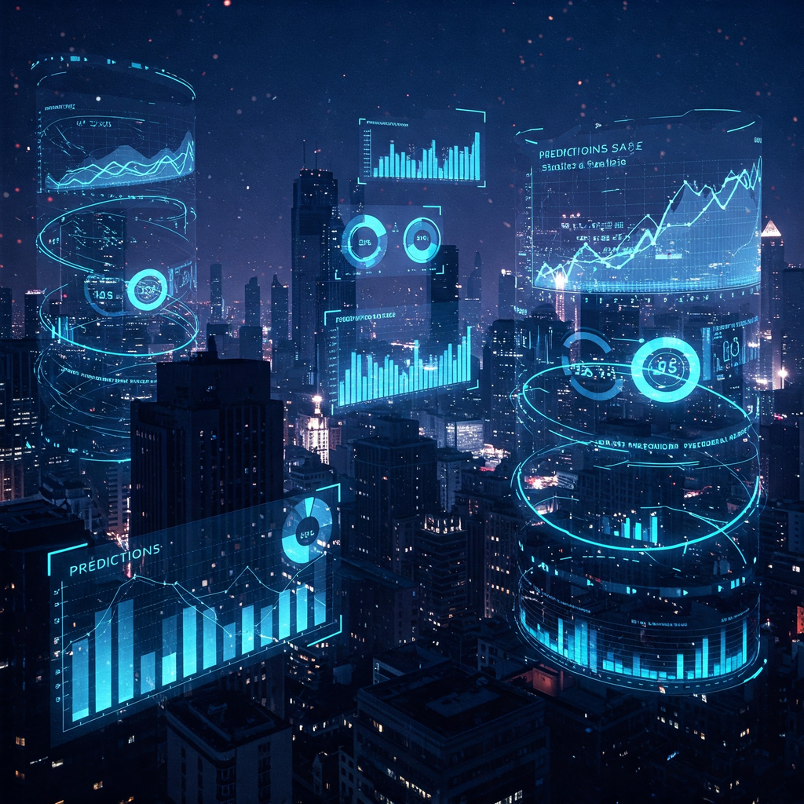

- We are all forecasters
  - How cold is it outside?
  - Is it more fun to go out or stay home?
  - What’s my life like if I study Economics? And if I walk barefoot to India?
  - If I take a student loan now, how will my financial situation be in 10 years?

### Some predictions from the past

- the end of history (Fukuyama, 1992)
  - no more conflict, uncertainty,…

. . .

- Democratization through open markets (liberal internationalists, 1990s–2000s)
  - “China/Russia will become more democratic”

. . .

- “The internet will liberate us.” (widespread, early 2000s)
  - Information $\Rightarrow$ freedom + productivity

. . .

**TipTakeaway**

Widely held beliefs can be entirely wrong.

### Right or wrong?

Somebody (maybe Niels Bohr):

“Prediction is very difficult, especially if it’s about the future!”

. . .

- Example: When Russia amassed troops in the winter of 2021–2022, many analysts deemed a large-scale invasion of Ukraine unlikely [@driedger2023utility].
  - If somebody says “Russia is not invading Ukraine”. Wrong.
  - If somebody says “It is unlikely”. In what sense is she wrong?
- Example: “Trump’s winning odds are 53.4 percent, over Harris’ 46.2 percent.” (remainder: third-party candidates)
  - Was Nate Silver’s forecast right? …good? …helpful?
  - Clearly, not the same as saying Trump will win.

### Some problems are more difficult than others

- many predictions work pretty well
  - We focus often on the difficult predictions (or the ones gone bad)
- some issues are more **difficult** to predict
  - “Does the flap of a butterfly’s wing cause a tornado?”
  - Chaos theory: Study of dynamic systems that are highly(!) sensitive to initial conditions
- Others are **easier** to predict
  - stable dynamic systems
  - or averages

### Pitfalls

- **human judgment** is (often/on average) heavily flawed
  - luckily if the bias is known, it can be accounted for

. . .

- there is a set of (psychological) skills that help
  - “superforecasters” [@tetlock2016superforecasting]

. . .

- Alternatively, one can use **data**…

### Data and predictions

- If humans are flawed, why not use computers (and statistical algorithms)?
  - **statistical learning** or **machine learning**

. . .

- **requires data** to perform well
  - much data: Cat and dog pictures
  - much data: Predict next word in text
  - little data: Is a certain business making money in 2025?
  - little data: Will humanity persist in 100 years?

. . .

- One solution: Structural modeling
  - combines human judgment and statistical learning
  - model incorporates human knowledge
  - algorithm make adequate predictions based on data
  - Example: The linear model
    $$\hat y = x\beta$$

### Subjective predictions (aka judgmental predictions)

- use judgment predictions if
  1. **no good data** are available for statistical predictions
  2. in **combination** with data
- will Machine Learning replace all human prediction skills?
  - short: no.
  - machine predictions always will need human checks
  - machine learning still mostly useful in narrow fields
  - important skill: use ML

### Summary

Predictions

- are important for decision making
- can be deterministic (“yes”/“no”) or probabilistic (“x%”)
- are sometimes simple, sometimes difficult
- sometimes right, sometimes wrong, sometimes partly right
- can be based on subjective judgment (always possible) and data and algorithms (better if good data is available)

## Formalities

### Hours

- 9.15 h to 11.45 h
- 30 minutes break in between
  - can be used for questions
- bring your laptop for programming exercises
- bring your laptop for AI quizzes (mobile phone might be fine)

### Syllabus

- A comprehensive approach to predictions that spans from
  - its decision-theoretic (microeconomic) foundations over
  - subjective judgments, economic expectation, and
  - prediction markets, market prices, as well as
  - machine learning.
- 15 lectures
  - optional topics on language models, AI forecasting, and Ambiguity
  - and exam preparation
- spotted with Exercises
  - for quizing and learning
  - for implementing
  - a forecast competition

### Where is the knowledge coming from?

- Statistics
- Computer Science
- Decision-Theory
- Psychology

1. Introduction to Decision Theory
- actions, consequences, and preferences
- uncertainty as probability and subjective expected utility
- dynamic consistency and Bayesian updating
- Exercise
2. Predictions and their properties
- point predictions vs probabilistic predictions
- mathematical framework: the prediction space setting
- calibration, accuracy, sharpness
- Optimal predictions
- Exercise

### Part 2: Predicting with subjective judgment (4 lectures)

3. Measurement and Elicitation
- elicitation procedures
- incentives
- Exercise: Define forecast target for competition
4. Evaluation methods
- calibration curves
- proper scoring rules and Diebold-Mariano Tests
- PIT diagram
- Mincer-Zarnowitz regression
- Programming Exercise: Empirical evaluation of predictions
5. Empirical findings on subjective predictions
- heuristics and biases
- characteristics of super forecasters
- Economic Expectations (Professionals, Businesses, Consumers)
- Exercise: Issue judgement predictions for forecast competition
6. Market-based predictions
- prediction markets
- efficient market hypothesis
- Programming Exercise

### Part 3: Statistical forecasts (4 lectures)

7. Monte-Carlo predictions
- structural generative models
- simulating random outcomes
- analyzing Monte-Carlo samples
- example: life-time saving choice as young adults
- Programming Exercise
8. Bayesian modelling
- Bayesian workflow: model, prior, posterior
- Markov-Chain-Monte-Carlo methods
- Posterior samples and convergence
- Probabilistic programming in Stan/Jags
- example: Monty-Hall problem and forecast combination
- Programming Exercise
9. Basics of Statistical Learning
- loss functions
- train, test, validate
- in-sample, out-of-sample, and cross-validation
- model complexity and the bias-variance tradeoff
- Programming Exercise
10. Deep learning
- Neural networks
- best practices
- Language models
- Programming Exercise: Issue statistical forecast for forecast competition

### Part 4: Other

12. Extra lecture on
    - Language Models and Predicting with AI or
    - Ambiguity
13. Evaluation forecast competition
14. Exam Preparation
15. **Exam** (probably on last lecture)

### Extra lectures if time and interest allows

20. Beyond Bayes: ambiguity and imprecise probabilities
- the Ellsberg Urn
- Ambiguity theory and robust decisions
20. Language models for judgment predictions
- introduction to language models
- limits and fine tuning
- reasoning and tool use

### Grading

- exam (100%): last lecture date
- Extra points for
  - finding and reporting AI fail cases
  - scoring high in forecast competition
  - Sidenote: Extra points cannot help with passing and are not necessary for achieving the best grade

### Recommendation

- learning preferences differ, but let me recommend…
- come to the lecture and exercise (3h)
  - ask questions
- afterwards: actively engage with the content (e.g., summarize it or discuss) (1h)
- before next lecture: quickly check the past content (30 minutes)
- spend some time on test questions and assignments (2h, but not evenly distributed)
- learning is effective if
  - engaged
  - slightly overwhelmed
  - rest and sleep

. . .

- testing, summarizing, and discussion is helpful
  - I will provide tests and suggestions to engage
- group work is great

. . .

- theory and statistics learning needs more breaks
- avoid binge learning

. . .

- try to focus on the content (not the exam)

### AI chatbot

- free access to a state-of-the-art language model
  - use for learning and assignments
  - has access to lecture materials
  - guidelines provided by me
- funded by a heiSKILLS Fellowships “AI in Teaching” from University of Heidelberg
- idea: Figure out how to best use AI for learning in higher-education
- AI might be wrong
  - you are encouraged to report fail cases
  - extra points for errors found
  - idea: foster critical thinking

Three extra points possible:

1. reported at least one simple fail cases: login, optics, almost anything
2. reported at least one logical mistake or unwanted behavior (okay if misleading prompts are used)
3. reported at least one deep logical mistake for sensible prompts (hard to find)
- registration at first login
  - use your uni-heidelberg mail
  - and a password
- do not share any private information
- logs of chats will be saved
  - used for improvements
  - you may receive mails with corrections

https://teachbot-production-2e85.up.railway.app/

[figure not shown]

### Literature

- there is no single text-book for this lecture
- For the broadly interested

Silver, N. (2012): The Signal and the Noise: Why So Many Predictions Fail-but Some Don’t, Penguin Press.

Tetlock, P. E., & Gardner, D. (2016). Superforecasting: The art and science of prediction. Random House.

Benjamin, D. J. (2019): “Errors in Probabilistic Reasoning and Judgment Biases.” Chapter 2 in *Handbook of Behavioral Economics*, Vol. 2, pp. 69–186.

James, G., Witten, D., Hastie, T., Tibshirani, R., & Taylor, J. (2023). An introduction to statistical learning: with applications in R. Second Edition. Spinger.

## Same same, but different

### Related topics that are not the focus…

[figure not shown]

- some things we will not cover here or only from an uncommon perspective

### Causality

- Famously:
  $$causality \neq correlation$$
- Similarly, good predictions are not necessarily helpful in revealing causal relationships.

### Estimation and testing

- Estimation is closely connected to predictions
  - Estimation is just predicting a parameter
- Hypothesis testing is the reduction of estimation to yes/no decisions
  - Decision making in relation to predictions will be covered
  - Testing is a sub-problem of decision making but will not receive special attention

### Linear Regression Model

- The linear regression model,

$$E[y|x]=x'\beta,$$

with the ordinary least squares (OLS) estimator

$$\hat \beta_{OLS} = \arg \min_\beta \sum (y_i-x_i'\beta)^2$$
is the workhorse of econometrics.

- In this lecture, the linear regression will take a backseat
- but will discuss its prediction properties
  $$\hat y = x'\hat \beta_{OLS}$$

historically based on convenient computational properties that are less crucial nowadays

### Time series

- forecasting is often taught from a time series perspective
  - many important predictions have time series format
- we will not cover time series modeling specifically
  - but some lessons learned here are applicable in time series forecasting

### Normative and descriptive approaches

- normative: How should things optimally be?
- descriptive: How are things actually?
- here:
  - Decisions: Normative approach
  - Subjective judgment predictions: Mostly descriptive approach
  - Statistical forecasting: Focus on application